# Description

### Course STAT 292

#### Semester Spring 2017

#### Content Statistics and Computer Science

#### Author [Enes Dilber](https://enesdilber.github.io/)

# 1 Statistics in Fuzzy Logic

In Boolean or two-valued logic, the truth values of a variable will always be either 0 or 1 and in traditional two-valued set theory, an element belongs to a set or not. Similar to this, in a typical classification problem, an observation is classified into one of several different classes. In all of these cases, there is a definitive true value. Fuzzy logic presents a different approach to these problems. In fuzzy logic, the truth value of a variable or the label (in a classification problem) is a real number between 0 and 1. For example, suppose you are in a pool with a friend. For you, the water is warm and for your friend, the water is cold. After a silly discussion between both of you, you decide to use a thermometer to measure the temperature, and it is 20C. So since both of you know the freezing and boiling point of water (0C and 100C), you said the water is 0.20 hot and your friend is said, it is 0.80 cold. In other words, for you and your friend, there is not an absolute truth about the state of the water.  
[A gentle introduction video](https://www.youtube.com/watch?v=r804UF8Ia4c)  
[Here is a nice R tutorial](http://juandes.github.io/FuzzyLogic-R/docs/fuzzy_tutorial)

# 2 Statistics in Cryptography

### Cryptanalysis

Cryptanalysis is used to breach cryptographic security systems and gain access to the contents of encrypted messages, even if the cryptographic key is unknown.

### Frequency analysis

In cryptanalysis, frequency analysis is the study of the frequency of letters or groups of letters in a ciphertext. The method is used as an aid to breaking classical ciphers.

```r
X = "fqfsyzwnslbfxfsjslqnxmhtruzyjwxhnjsynxyrfymjrfynhnfsqtlnhnfs…"
```

```r
print(X)
```

```
[1] "fqfsyzwnslbfxfsjslqnxmhtruzyjwxhnjsynxyrfymjrfynhnfsqtlnhnfs…"
```

### Encryption

Encryption turns data into a series of unreadable characters, that aren't of a fixed length. The key difference between encryption and hashing is that encrypted strings can be reversed back into their original decrypted form if you have the right key.
$$ text_{encrypted} = F(text,\ key) $$ $$ text = F^{-1}(text_{encrypted},\ key) $$

### Letter frequency in English

Taken from wikiwand.com/en/Letter_frequency

```r
freqs_en = c(8.167,1.492,2.782,4.253,12.702,2.228,2.015,6.094,6.966,0.153,0.772,4.025,2.406,
             6.749,7.507,1.929,0.095,5.987,6.327,9.056,2.758,0.978,2.36,0.15,1.974,0.074)

df = data.frame(letter =  letters, freq = freqs_en)
df$letter = factor(df$letter, levels(df$letter)[order(-df$freq)])

options(repr.plot.width=5, repr.plot.height=3)
library(ggplot2)
```

In a simple substitution cipher, each letter of the plaintext is replaced with another, and any particular letter in the plaintext will always be transformed into the same letter in the ciphertext. For instance, if all occurrences of the letter e turn into the letter X, a ciphertext message containing numerous instances of the letter X would suggest to a cryptanalyst that X represents e. The key idea here is, we are going to use english letter frequency as a prior knowledge and going to macth the histogram of encrypted text with english freqency histogram. Lets plot histogram of our encrypted text:

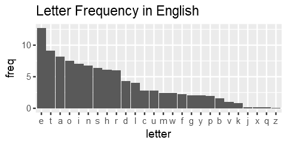

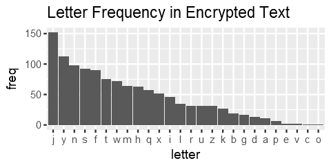

```r
freqs_text = sapply(letters, function(x) sum(x==unlist(strsplit(X,""))))

df2 = data.frame(letter =  names(freqs_text), freq = freqs_text)
df2$letter = factor(df2$letter, levels(df2$letter)[order(-df2$freq)])

options(repr.plot.width=4, repr.plot.height=2)
library(ggplot2)
ggplot(data=df, aes(x=letter, y=freq)) +
    geom_bar(stat="identity") + ggtitle("Letter Frequency in English")
ggplot(data=df2, aes(x=letter, y=freq)) +
    geom_bar(stat="identity") + ggtitle("Letter Frequency in Encrypted Text")
```

Suppose the person who encrypt the text, has just shift the letters with a shifting constant. That means the $key$ is just shifting constant. For example if the key is $3$ all $a$'s replaced by $d$, $b$'s with $e$, ..., $z$'s with $c$. To infer this constant we could look the difference between highest frequency number. In our context, it is $j$. So if we substract $e$ from $j$ we got $5$ index wise.

```r
which(letters == levels(df2$letter)[1]) - which(letters == levels(df$letter)[1])
```

5

Here is an implementation of *text shifter*.

```r
crypt = function(X, shift = 20){
  letters_x = letters
  for(i in shift:26) letters_x[i-shift] = letters[i]
  for(i in 1:shift) letters_x[26-shift+i] = letters[i]

  X = unlist(strsplit(x = X, split = ""))

  return(
      paste(
          unlist(
              sapply(X, function(x) return(letters_x[which(letters ==x)]))), collapse = ""))
}
```

Since crypted text shifted by 5, we could recover it by shifting 21. Because english has 26 letters.

```r
X_c = crypt(X, 26-5)
print(X_c)
```

```
[1] "alanturingwasanenglishcomputerscientistmathematicianlogician…"
```

Key could be something else. For example it could be a random order of the letters. For example:

```r
Let = rbind(letters, sample(letters))
rownames(Let) = c("original", "replacement")
Let
```

| original | a | b | c | d | e | f | g | h | i | j | ... | q | r | s | t | u | v | w | x | y | z |
| --- | --- | --- | --- | --- | --- | --- | --- | --- | --- | --- | --- | --- | --- | --- | --- | --- | --- | --- | --- | --- | --- |
| replacement | q | c | m | r | e | u | p | j | y | f | ... | i | z | t | s | w | x | d | k | l | h |

In this case, shifting $key$ is not a single value but a vector of shifts. This is harder to decrypt. One should also consider most common bigrams and trigrams. The important concept here is, we are able to decrypt the message without knowing the key. Day by day statistics play an important role in cryptoanalysis. Statistical attacks becoming more successful than mathematical or algebraic ones. [Here is the resources of Cryptanalysis course of UCL](http://blog.bettercrypto.com/?page_id=1368)

# 3 Statistics in Artificial Intelligence

The most common application of statistics in computer science is the field of Artificial Intelligence. Rule-based approach of programming does not apply the real life situations. In real life experience plays an important role in action. Therefore AI and Statistics intersect at -*some*- ML algorithms.

### Machine Learning

Tom Mitchell defines ML algorithms as:

- improve their performance (P)
- at some task (T)
- with experience (E)

Roughly, we can define them in statistics perspective as:

- **P** is How good is the model fit in Test set (GOF and other measures).
- **T** is Representing (Modeling) Dependent Variable(s) with Independent Variable(s) ($Y\sim \beta X+\epsilon$, Regression etc.)
- **E** is Training Data

Here is an algorithm guide in python package scikit learn:

[figure not shown]

#### ML algorithms in STAT cirruculum:

- Regression: 363-364
- Classification: 364, 412
- Clustering: 412, 467
- Dimensionality Reduction: 412, 467

### Illustrative Example

Suppose we want to predict the admission of a student with the information of their gre and gpa scores with the ranking of their school.

```r
E = read.csv("https://stats.idre.ucla.edu/stat/data/binary.csv")[1:300,]
head(E)
```

| admit | gre | gpa | rank |
| --- | --- | --- | --- |
| 0 | 380 | 3.61 | 3 |
| 1 | 660 | 3.67 | 3 |
| 1 | 800 | 4.00 | 1 |
| 1 | 640 | 3.19 | 4 |
| 0 | 520 | 2.93 | 4 |
| 1 | 760 | 3.00 | 2 |

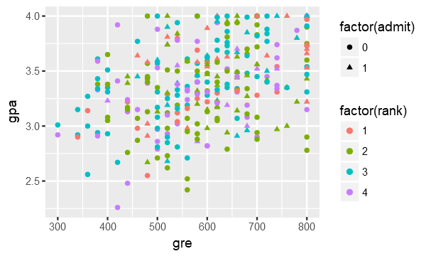

```r
options(repr.plot.width=5, repr.plot.height=3)
ggplot(E, aes(x=gre, y=gpa, color=factor(rank), shape = factor(admit))) + geom_point()
```

It is so hard to find a rule for admission by looking at this plot. Let's compare variables with admission one by one.

### Rule-Based Methods:

```r
GRE_mean = aggregate(E$gre, by = list(E$admit), mean)
GPA_mean = aggregate(E$gpa, by = list(E$admit), mean)
Rank_rat = aggregate(E$admit, by = list(E$rank), mean)
```

```r
paste("GRE mean for admitted students is", round(GRE_mean$x[2]),"and for rejected ones it is", round(GRE_mean$x[1]))
```

'GRE mean for admitted students is 630 and for rejected ones it is 573'

```r
paste("GPA mean for admitted students is", round(GPA_mean$x[2],2),"and for rejected ones it is", round(GPA_mean$x[1],2))
```

'GPA mean for admitted students is 3.5 and for rejected ones it is 3.34'

```r
paste("Admission percentages by ranking of their colleges are:", paste(round(Rank_rat[,2],2), collapse = ", " ))
```

'Admission percentages by ranking of their colleges are: 0.56, 0.36, 0.21, 0.16'

We can intiutively recognize some patterns about admission by above information. For example we could say: If college rank of the person is 1 and its GPA > 3.5 result is admission. Or her/his GRE > 620 , GPA > 3.8, College rank $\in$ {1,2} result is admission. Suppose we want to predict the admission of new students based on our rules. Lets implement a rule based prediction function:  
$(rank \in {3,4})\land (GPA>3.7) \land (GRE>650) \Rightarrow admit$  
$(rank \in {2})\land (GPA>3.6) \land (GRE>640) \Rightarrow admit$  
$(rank \in {1})\land (GPA>3.4) \land (GRE>620) \Rightarrow admit$  
reject in other situations.

```r
predict_rb = function(x){
    ifelse(x$rank %in% c(3,4) && x$gpa > 3.7 && x$gre > 650, 1,
           ifelse(x$rank %in% c(2) && x$gpa > 3.6 && x$gre > 640, 1,
                  ifelse(x$rank %in% c(1) && x$gpa > 3.4 && x$gre > 620, 1, 0)))
}
```

Let's predict admission of some students:

```r
predict_rb(list(rank = 1, gpa = 3.62, gre = 700))
```

1

```r
predict_rb(list(rank = 3, gpa = 4.00, gre = 700))
```

1

```r
predict_rb(list(rank = 2, gpa = 2.5, gre = 600))
```

0

Suppose, now we have a new set of students to predict. Here is their information:

```r
new_students = read.csv("https://stats.idre.ucla.edu/stat/data/binary.csv")[301:400, -1]
head(new_students)
```

|  | gre | gpa | rank |
| --- | --- | --- | --- |
| 301 | 640 | 3.30 | 2 |
| 302 | 660 | 3.60 | 3 |
| 303 | 400 | 3.15 | 2 |
| 304 | 680 | 3.98 | 2 |
| 305 | 220 | 2.83 | 3 |
| 306 | 580 | 3.46 | 4 |

Now we are going to predict their admission status with our rule based method:

```r
Y_hat = sapply(1:100, function(i) predict_rb(new_students[i, ]))
Y_hat
```

1. 0

2. 0

3. 0

4. 1

5. 0

6. 0

7. 0

8. 0

9. 0

10. 0

11. 0

12. 1

13. 1

14. 0

15. 0

16. 0

17. 0

18. 0

19. 0

20. 0

21. 0

22. 0

23. 0

24. 0

25. 0

26. 1

27. 0

28. 0

29. 0

30. 0

31. 1

32. 0

33. 0

34. 0

35. 0

36. 0

37. 0

38. 0

39. 0

40. 0

41. 0

42. 0

43. 0

44. 0

45. 0

46. 0

47. 0

48. 0

49. 0

50. 0

51. 1

52. 0

53. 0

54. 0

55. 0

56. 0

57. 0

58. 0

59. 0

60. 1

61. 0

62. 0

63. 0

64. 0

65. 0

66. 0

67. 0

68. 0

69. 0

70. 1

71. 0

72. 1

73. 0

74. 0

75. 0

76. 0

77. 0

78. 1

79. 0

80. 0

81. 1

82. 0

83. 0

84. 1

85. 0

86. 0

87. 1

88. 0

89. 0

90. 0

91. 0

92. 1

93. 0

94. 0

95. 0

96. 0

97. 0

98. 0

99. 1

100. 0

Suppose the results are announced and you want to check your prediction success:

```r
results = read.csv("https://stats.idre.ucla.edu/stat/data/binary.csv")[301:400, 1]
table(results, Y_hat)
```

```
       Y_hat
results  0  1
      0 56  9
      1 29  6
```

$Prediction\ Success = \frac{56+6}{56+9+29+6} = 0.62$

### Statistical Model:

```r
E$rank = as.factor(E$rank)
E$admit = as.factor(E$admit)
model = glm(admit ~ gre + gpa + rank, data = E, family = binomial())
```

```r
new_students$rank = as.factor(new_students$rank)
Y_hat_log = ifelse(predict.glm(object = model, newdata = new_students, type = "response")>0.5,1,0)
table(results, Y_hat_log)
```

```
       Y_hat_log
results  0  1
      0 57  8
      1 25 10
```

$Prediction\ Success = \frac{57+10}{57+8+25+10} = 0.67$

Detailed version of the example: [LOGIT REGRESSION | R DATA ANALYSIS EXAMPLES](https://stats.idre.ucla.edu/r/dae/logit-regression/)

Statistical Models help machines to learn the pattern. Imagine a more complex task. Suppose you want to program an AI system that recognize trees. You could specify shape of a tree. For example leaves, branches and roots. However there is not only one type of tree. There are thousands of them. We need to find a pattern that is common for all trees and not in other objects.

### Advanced Methods:

Neural Networks: [Playground](https://playground.tensorflow.org/)

# 4 Statistical Programming

### $\lambda-Calculus$ :

It is a universal model of computation that can be used to simulate any Turing machine. It was first introduced by mathematician Alonzo Church (Advisor of Alan Turing) in the 1930s as part of his research of the foundations of mathematics. [An introductary video for Lambda Calculus](https://www.youtube.com/watch?v=eis11j_iGMs)

## Functional Programming

Functional programming has its origins in lambda calculus, a formal system developed in the 1930s to investigate computability, the Entscheidungsproblem, function definition, function application, and recursion. Many functional programming languages can be viewed as elaborations on the lambda calculus.  
[An introductary video for Functional Programming](https://www.youtube.com/watch?v=eis11j_iGMs)

R, at its heart, is a functional programming (FP) language. This means that it provides many tools for the creation and manipulation of functions. In particular, R has what’s known as first class functions. You can do anything with functions that you can do with vectors: you can assign them to variables, store them in lists, pass them as arguments to other functions, create them inside functions, and even return them as the result of a function.  
[Functional Programming in R from A. Hickham](http://adv-r.had.co.nz/Functional-programming.html)  
[Functional Programming in R from Mailund, Thomas](https://www.apress.com/gp/book/9781484227459)

## 4.1 Loops in $R$

### Imperative Programming

```r
total = 0
i = 0

while(i<=10){
    total = total + i
    i = i + 1
}

print(total)
```

```
[1] 55
```

### Functional Programming

```r
print(sum(1:10)) #built-in functions write loops in C++
```

```
[1] 55
```

#### Using Recursion to avoid loops:

```r
rec_sum = function(x){
    if(length(x) == 1){
        return(x) # reached to singleton
    }else{
        return(x[1] + rec_sum(x[-1]))
    }
} #no variable, no object, no outside sources, no side effects!

print(rec_sum(1:10))
```

```
[1] 55
```

#### A loop function

```r
x = 1:10
for(i in 1:10){
    x[i] = x[i] - 2
}
x
```

1. -1

2. 0

3. 1

4. 2

5. 3

6. 4

7. 5

8. 6

9. 7

10. 8

```r
For = function(operation, my_sequence){

    my_sequence[1] = operation(my_sequence[1])

    if(length(my_sequence) == 1) return(my_sequence)

    return(c(my_sequence[1],
             For(operation, my_sequence[-1])))
}

For(operation = function(x) x-2, my_sequence = 1:10)
```

1. -1

2. 0

3. 1

4. 2

5. 3

6. 4

7. 5

8. 6

9. 7

10. 8

### Currying:

```r
f = function(x, y) x - y
h = function(x) function(y) f(x, y)
sapply(1:4, h(2))
```

1. 1

2. 0

3. -1

4. -2

A function such as h, one that takes a sequence of parameters not in a single function call but through a sequence of function calls, each taking a single parameter and returning a new function, is known as a curried function. What we did to transform f into h is called currying f. The name refers to the logician Haskell Curry, from whom we also get the name of the functional programming language Haskell.

```r
curry = function(f)
function(x) function(y) f(x, y)
```

```r
h = curry(`-`)
sapply(1:10, h(2))
```

1. 1

2. 0

3. -1

4. -2

5. -3

6. -4

7. -5

8. -6

9. -7

10. -8

## 4.2 Filter, Map, and Reduce (Smart way to avoid Loops)

### Filter:

```r
is_divisible = function(x) function(y) y %% x == 0

unlist(Filter(is_divisible(13), 1:100))
```

1. 13

2. 26

3. 39

4. 52

5. 65

6. 78

7. 91

### Map :

```r
unlist(Map(`+`, 1:5, 1:5))
```

1. 2

2. 4

3. 6

4. 8

5. 10

```r
unlist(Map(`+`, 2, 1:5)) # Broadcasting
```

1. 3

2. 4

3. 5

4. 6

5. 7

### Reduce:

While Filter and Map produce lists, the Reduce function transforms a list into a value. Of course that value can also be a list, since lists are also values, but Reduce doesn’t simply process each element in its input list independently. Instead, it summarizes the list by applying a function iteratively to pairs. You provide it a function, $f$, of two elements, and it will first call $f$ on the first two elements in the list. Then it will take the result of this and call $f$ with this and the next element, and continue doing that through the list. So calling $Reduce(f, 1:5)$ will be equivalent to calling:  
$f(f(f(f(1, 2), 3), 4), 5)$ (recall recursion)

```r
Reduce(`+`, 1:5)
```

15

```r
Reduce(`+`, 1:5, accumulate = TRUE)
```

1. 1

2. 3

3. 6

4. 10

5. 15

```r
samples = replicate(3, sample(1:10, replace = TRUE), simplify = FALSE)
print(samples)
```

```
[[1]]
 [1] 9 6 9 6 6 8 5 2 9 9

[[2]]
 [1]  8  8  2  4  8  3  7  1 10  1

[[3]]
 [1] 3 9 1 7 2 9 3 2 1 5
```

```r
Reduce(intersect, samples)
```

2

## sapply, vapply, and lapply

```r
sapply(list(runif(1000),
            rnorm(2000),
            rexp(100, 1/2)), function(x) mean(x))
```

1. 0.507288556011394

2. -0.0389077795949474

3. 2.19314451401941

```r
x = rexp(n = 1000, rate = 1/4)

funs = list(
  sum = sum,
  mean = mean,
  sd = function(x) sqrt(var(x)),
  median = median
)

round(sapply(funs, function(f) f(x)), 2)
```

**sum**

4036.63

**mean**

4.04

**sd**

4.12

**median**

2.92

## apply

```r
set.seed(1)
apply(X = cbind(runif(100),
                rnorm(100),
                rexp(100, 1/2)),
      MARGIN = 2,
      FUN = function(x) mean(x))
```

1. 0.517847064710222

2. -0.017579492930548

3. 1.84572962389463

```r
set.seed(1)
apply(X = rbind(runif(100),
                rnorm(100),
                rexp(100, 1/2)),
      MARGIN = 1,
      FUN = function(x) mean(x))
```

1. 0.517847064710222

2. -0.017579492930548

3. 1.84572962389463

## 4.3 Side effects, Enviorment and Closure

```r
adder = function(x){
    x <- x + 2
    return(x)
}

x = 3

print(paste("initial value =", x))
print(paste("function return =", adder(x)))
print(paste("final value =", x))
```

```
[1] "initial value = 3"
[1] "function return = 5"
[1] "final value = 3"
```

```r
adder = function(x){
    x <<- x + 2
    return(x)
}

x = 3

print(paste("initial value =", x))
print(paste("function return =", adder(x)))
print(paste("final value =", x))
```

```
[1] "initial value = 3"
[1] "function return = 3"
[1] "final value = 5"
```

```r
adder = function(x){
    function(){
    x <<- x + 2
    return(x)
    }
}

x = 3

print(paste("initial value =", x))
print(paste("function return =", adder(x)()))
print(paste("final value =", x))
```

```
[1] "initial value = 3"
[1] "function return = 5"
[1] "final value = 3"
```

```r
adder = function(x){
    function(){
        assign("x", x+2, envir=globalenv())
        return(x)
    }
}

x = 3

print(paste("initial value =", x))
print(paste("function return =", adder(x)()))
print(paste("final value =", x))
```

```
[1] "initial value = 3"
[1] "function return = 3"
[1] "final value = 5"
```

## 4.4 Power of Linear Algebra

Not only functional programming tricks make your code tidy and faster, but also mathematical tricks could do that.

```r
X = read.table("https://raw.githubusercontent.com/enesdilber/datasets/master/multinorm.csv",
                header = FALSE, sep = ",")
X = as.matrix(X)

cat("First 5x5 instances:")
round(X[1:5, 1:5], 2)
cat("Size of the matrix:")
print(object.size(X), units = "Mb")
```

```
First 5x5 instances:
```

| V1 | V2 | V3 | V4 | V5 |
| --- | --- | --- | --- | --- |
| -0.70 | 3.77 | -3.62 | -1.50 | 2.63 |
| 2.59 | 1.16 | -2.54 | 1.44 | 1.52 |
| -2.16 | 5.91 | -2.97 | 3.54 | 0.50 |
| 3.40 | -0.16 | -7.53 | -3.50 | 0.01 |
| -2.13 | 2.18 | -0.91 | -0.06 | -3.61 |

```
Size of the matrix:5.7 Mb
```

## Calculating Variance-Covariance Matrix: Nested Loops

```r
VarCov_loop = function(x){
    #column means by for loop
    p = dim(x)[2]
    S = diag(apply(x, 2, var)) #diagonal is equal to column variance of x in var-cov matrix

    for(i in 1:(p-1)){

        for(j in (i+1):p){

            S[i, j] = S[j, i] = cov(x[, i], x[, j]) #Cov(X1, X2) = Cov(X2, X1)
        }
    }

    return(S)
}
```

```r
calc_time = function(f){

    Time = proc.time()
    Output = f()
    Time = proc.time() - Time

    return(list("Output" = Output, "Time" = Time))
}
```

```r
VC_loop = calc_time(function() VarCov_loop(X))

cat("Elapsed Time:")
VC_loop$Time
cat("First 5x5 instances:")
round(VC_loop$Output[1:5, 1:5], 2)
```

```
Elapsed Time:
```

```
   user  system elapsed
  10.98    0.00   11.04
```

```
First 5x5 instances:
```

| 10.66 | 0.77 | 0.93 | 0.70 | 1.04 |
| --- | --- | --- | --- | --- |
| 0.77 | 10.76 | 1.43 | 1.58 | 1.27 |
| 0.93 | 1.43 | 10.67 | 1.41 | 1.18 |
| 0.70 | 1.58 | 1.41 | 10.89 | 0.81 |
| 1.04 | 1.27 | 1.18 | 0.81 | 10.93 |

## Calculating Variance-Covariance Matrix: Matrix Multiplication

From basic statistics courses, we know that empirical variance formula could be written in this form:

$$ S_n = \frac{1}{n} \biggl(\sum x_i^2 - \frac{(\sum x_i)^2}{n}\biggr) \tag{1} $$

$$ \sum x_i^2 = X^TX $$

$$ \sum x_i = X^T1_n $$

By using this notations we could rewrite 1<sup>st</sup> equation in matrix form:

$$ S_n = \frac{1}{n} \bigl(X^TX-\frac{1}{n}X^T1_n1_n^TX\bigr) \tag{2} $$

Now let's implement it in R! Again, i will compare its performance with looped version.

```r
VarCov_matrix = function(x){
    #column means by matrix multiplication
    n = dim(x)[1]
    n1 = matrix(1, n, 1) #n dimentional 1 vector

    S = (1/n)*(t(x)%*%x - (1/n)*(t(x)%*%n1%*%t(n1)%*%x))

    return(S)
}
```

```r
VC_matrix = calc_time(function() VarCov_matrix(X))

cat("Elapsed Time:")
VC_matrix$Time
#cat("First 5x5 instances:")
#round(VC_matrix$Output[1:5, 1:5], 2)
```

```
Elapsed Time:
```

```
   user  system elapsed
   0.72    0.00    0.72
```

## Calculating Variance-Covariance Matrix: Built-in Function

```r
VC_builtin = calc_time(function() cov(X))

cat("Elapsed Time:")
VC_builtin$Time
cat("First 5x5 instances:")
round(VC_builtin$Output[1:5, 1:5], 2)
```

```
Elapsed Time:
```

```
   user  system elapsed
   0.33    0.00    0.36
```

```
First 5x5 instances:
```

|  | V1 | V2 | V3 | V4 | V5 |
| --- | --- | --- | --- | --- | --- |
| V1 | 10.66 | 0.77 | 0.93 | 0.70 | 1.04 |
| V2 | 0.77 | 10.76 | 1.43 | 1.58 | 1.27 |
| V3 | 0.93 | 1.43 | 10.67 | 1.41 | 1.18 |
| V4 | 0.70 | 1.58 | 1.41 | 10.89 | 0.81 |
| V5 | 1.04 | 1.27 | 1.18 | 0.81 | 10.93 |

## 4.5 When to Use Control Statements in $R$

```r
Dexp = function(x, rate) rate*exp(-rate*x)
#Dexp = function(l) function(x) l*exp(-l*x)
```

```r
print(Dexp(x = 0.1, rate = 2)) #user
print(dexp(x = 0.1, rate = 2)) #built-in
```

```
[1] 1.637462
[1] 1.637462
```

## Indicator function

```r
print(Dexp(x = -0.1, rate = 2)) #user
print(dexp(x = -0.1, rate = 2)) #built-in
```

```
[1] 2.442806
[1] 0
```

```r
Dexp = function(x, rate) (x>=0)*rate*exp(-rate*x)
```

```r
print(Dexp(x = -0.1, rate = 2)) #user
print(dexp(x = -0.1, rate = 2)) #built-in
```

```
[1] 0
[1] 0
```

## Expectation

```r
integrate(f = function(x) x*dexp(x = x, rate = 2), lower = -Inf, upper = Inf) #built-in
integrate(f = function(x) x*Dexp(x = x, rate = 2), lower = -Inf, upper = Inf) #user
```

```
0.5 with absolute error < 8.6e-06
```

```
Error in integrate(f = function(x) x * Dexp(x = x, rate = 2), lower = -Inf, : non-finite function value
Traceback:

1. integrate(f = function(x) x * Dexp(x = x, rate = 2), lower = -Inf,
 .     upper = Inf)
```

```r
Dexp = function(x, rate){
    ifelse(x>=0, return(rate*exp(-rate*x)), return(0))
}
```

```r
integrate(f = function(x) x*dexp(x = x, rate = 2), lower = -Inf, upper = Inf) #built-in
integrate(f = function(x) x*Dexp(x = x, rate = 2), lower = -Inf, upper = Inf) #user
```

```
0.5 with absolute error < 8.6e-06
```

```
0.5 with absolute error < 8.6e-06
```